# INFSCI 2595 Spring 2024 Final Project

SHUSRITA VENUGOPAL

2024-04-16

# Load packages

The modelr package is loaded in the code chunk below. From modelr we could use functions to calculate performance metrics for your models.

```r
library(modelr)
```

# Loading the dataset

```r
train_dataset_csv <- 'paint_project_train_data.csv'

train_dataset <- readr::read_csv(train_dataset_csv, col_names = TRUE)
```

# A glimpse of the data

```r
train_dataset |> glimpse()
```

```
## Rows: 835
## Columns: 8
## $ R          <dbl> 172, 26, 172, 28, 170, 175, 90, 194, 171, 122, 0, 88, 144, …
## $ G          <dbl> 58, 88, 94, 87, 66, 89, 78, 106, 68, 151, 121, 140, 82, 163…
## $ B          <dbl> 62, 151, 58, 152, 58, 65, 136, 53, 107, 59, 88, 58, 132, 50…
## $ Lightness  <chr> "dark", "dark", "dark", "dark", "dark", "dark", "dark", "da…
## $ Saturation <chr> "bright", "bright", "bright", "bright", "bright", "bright",…
## $ Hue        <dbl> 4, 31, 8, 32, 5, 6, 34, 10, 1, 21, 24, 22, 36, 16, 26, 12, …
## $ response   <dbl> 12, 10, 16, 10, 11, 16, 10, 19, 14, 25, 14, 19, 14, 38, 15,…
## $ outcome    <dbl> 1, 1, 1, 0, 0, 0, 0, 0, 0, 0, 0, 0, 0, 0, 0, 0, 0, 0, 1, 1,…
```

R, G, B (Red, Green, Blue): Components of the RGB color model representing the intensity of red, green, and blue in the paint color. Lightness: Categorizes the paint color into different levels of darkness or lightness. Saturation: Represents the intensity or purity of the color, categorizing it into different levels of brightness. Hue: Indicates the color attribute of the paint, distinguishing it as red, blue, yellow, etc., represented as an angle in the HSL color model. Response: A continuous output representing an important paint property. Outcome: A binary output indicating the popularity of the paint color, with 1 denoting popular colors and 0 denoting less popular ones.

# Data Exploration

## Convert categorical data into numerical form using label encoding

```r
# Convert Lightness to numerical values
train_dataset$LightnessNum <- as.integer(factor(train_dataset$Lightness, levels = unique(train_dataset$Lightness)))

# Convert Saturation to numerical values
train_dataset$SaturationNum <- as.integer(factor(train_dataset$Saturation, levels = unique(train_dataset$Saturation)))

train_dataset |> glimpse()
```

```
## Rows: 835
## Columns: 10
## $ R             <dbl> 172, 26, 172, 28, 170, 175, 90, 194, 171, 122, 0, 88, 14…
## $ G             <dbl> 58, 88, 94, 87, 66, 89, 78, 106, 68, 151, 121, 140, 82, …
## $ B             <dbl> 62, 151, 58, 152, 58, 65, 136, 53, 107, 59, 88, 58, 132,…
## $ Lightness     <chr> "dark", "dark", "dark", "dark", "dark", "dark", "dark", …
## $ Saturation    <chr> "bright", "bright", "bright", "bright", "bright", "brigh…
## $ Hue           <dbl> 4, 31, 8, 32, 5, 6, 34, 10, 1, 21, 24, 22, 36, 16, 26, 1…
## $ response      <dbl> 12, 10, 16, 10, 11, 16, 10, 19, 14, 25, 14, 19, 14, 38, …
## $ outcome       <dbl> 1, 1, 1, 0, 0, 0, 0, 0, 0, 0, 0, 0, 0, 0, 0, 0, 0, 0, 1,…
## $ LightnessNum  <int> 1, 1, 1, 1, 1, 1, 1, 1, 1, 1, 1, 1, 1, 1, 1, 1, 1, 1, 1,…
## $ SaturationNum <int> 1, 1, 1, 1, 1, 1, 1, 1, 1, 1, 1, 1, 1, 1, 1, 1, 1, 1, 2,…
```

## Create a new column “y” which represents the logit transformed response column

```r
# Calculate logit transformed response
train_dataset$y <- boot::logit((train_dataset$response - 0) / (100 - 0))
train_dataset |> glimpse()
```

```
## Rows: 835
## Columns: 11
## $ R             <dbl> 172, 26, 172, 28, 170, 175, 90, 194, 171, 122, 0, 88, 14…
## $ G             <dbl> 58, 88, 94, 87, 66, 89, 78, 106, 68, 151, 121, 140, 82, …
## $ B             <dbl> 62, 151, 58, 152, 58, 65, 136, 53, 107, 59, 88, 58, 132,…
## $ Lightness     <chr> "dark", "dark", "dark", "dark", "dark", "dark", "dark", …
## $ Saturation    <chr> "bright", "bright", "bright", "bright", "bright", "brigh…
## $ Hue           <dbl> 4, 31, 8, 32, 5, 6, 34, 10, 1, 21, 24, 22, 36, 16, 26, 1…
## $ response      <dbl> 12, 10, 16, 10, 11, 16, 10, 19, 14, 25, 14, 19, 14, 38, …
## $ outcome       <dbl> 1, 1, 1, 0, 0, 0, 0, 0, 0, 0, 0, 0, 0, 0, 0, 0, 0, 0, 1,…
## $ LightnessNum  <int> 1, 1, 1, 1, 1, 1, 1, 1, 1, 1, 1, 1, 1, 1, 1, 1, 1, 1, 1,…
## $ SaturationNum <int> 1, 1, 1, 1, 1, 1, 1, 1, 1, 1, 1, 1, 1, 1, 1, 1, 1, 1, 2,…
## $ y             <dbl> -1.9924302, -2.1972246, -1.6582281, -2.1972246, -2.09074…
```

```r
# Check the data types of each column
str(train_dataset)
```

```
## spc_tbl_ [835 × 11] (S3: spec_tbl_df/tbl_df/tbl/data.frame)
##  $ R            : num [1:835] 172 26 172 28 170 175 90 194 171 122 ...
##  $ G            : num [1:835] 58 88 94 87 66 89 78 106 68 151 ...
##  $ B            : num [1:835] 62 151 58 152 58 65 136 53 107 59 ...
##  $ Lightness    : chr [1:835] "dark" "dark" "dark" "dark" ...
##  $ Saturation   : chr [1:835] "bright" "bright" "bright" "bright" ...
##  $ Hue          : num [1:835] 4 31 8 32 5 6 34 10 1 21 ...
##  $ response     : num [1:835] 12 10 16 10 11 16 10 19 14 25 ...
##  $ outcome      : num [1:835] 1 1 1 0 0 0 0 0 0 0 ...
##  $ LightnessNum : int [1:835] 1 1 1 1 1 1 1 1 1 1 ...
##  $ SaturationNum: int [1:835] 1 1 1 1 1 1 1 1 1 1 ...
##  $ y            : num [1:835] -1.99 -2.2 -1.66 -2.2 -2.09 ...
##  - attr(*, "spec")=
##   .. cols(
##   ..   R = col_double(),
##   ..   G = col_double(),
##   ..   B = col_double(),
##   ..   Lightness = col_character(),
##   ..   Saturation = col_character(),
##   ..   Hue = col_double(),
##   ..   response = col_double(),
##   ..   outcome = col_double()
##   .. )
##  - attr(*, "problems")=<externalptr>
```

```r
# Check summary statistics for numerical columns
summary(train_dataset)
```

```
##        R               G               B          Lightness
##  Min.   :  0.0   Min.   : 58.0   Min.   : 47.0   Length:835
##  1st Qu.:147.0   1st Qu.:138.0   1st Qu.:112.5   Class :character
##  Median :203.0   Median :188.0   Median :170.0   Mode  :character
##  Mean   :183.3   Mean   :176.3   Mean   :160.3
##  3rd Qu.:229.5   3rd Qu.:222.0   3rd Qu.:211.0
##  Max.   :255.0   Max.   :241.0   Max.   :238.0
##   Saturation             Hue           response       outcome
##  Length:835         Min.   : 1.00   Min.   : 6.0   Min.   :0.0000
##  Class :character   1st Qu.: 9.00   1st Qu.:26.0   1st Qu.:0.0000
##  Mode  :character   Median :17.00   Median :51.0   Median :0.0000
##                     Mean   :17.68   Mean   :48.6   Mean   :0.2287
##                     3rd Qu.:26.00   3rd Qu.:72.0   3rd Qu.:0.0000
##                     Max.   :36.00   Max.   :87.0   Max.   :1.0000
##   LightnessNum   SaturationNum         y
##  Min.   :1.000   Min.   :1.000   Min.   :-2.75154
##  1st Qu.:2.000   1st Qu.:2.500   1st Qu.:-1.04597
##  Median :4.000   Median :4.000   Median : 0.04001
##  Mean   :4.012   Mean   :4.103   Mean   :-0.10936
##  3rd Qu.:6.000   3rd Qu.:6.000   3rd Qu.: 0.94446
##  Max.   :7.000   Max.   :7.000   Max.   : 1.90096
```

Based on the output, we can categorize the columns as follows:

1. Continuous columns (numerical):R, G, B, Hue.
2. Binary columns (numerical): outcome.
3. Categorical columns: Lightness, Saturation.

### To visualize the counts for categorical variables in the dataset, we can use bar plots.

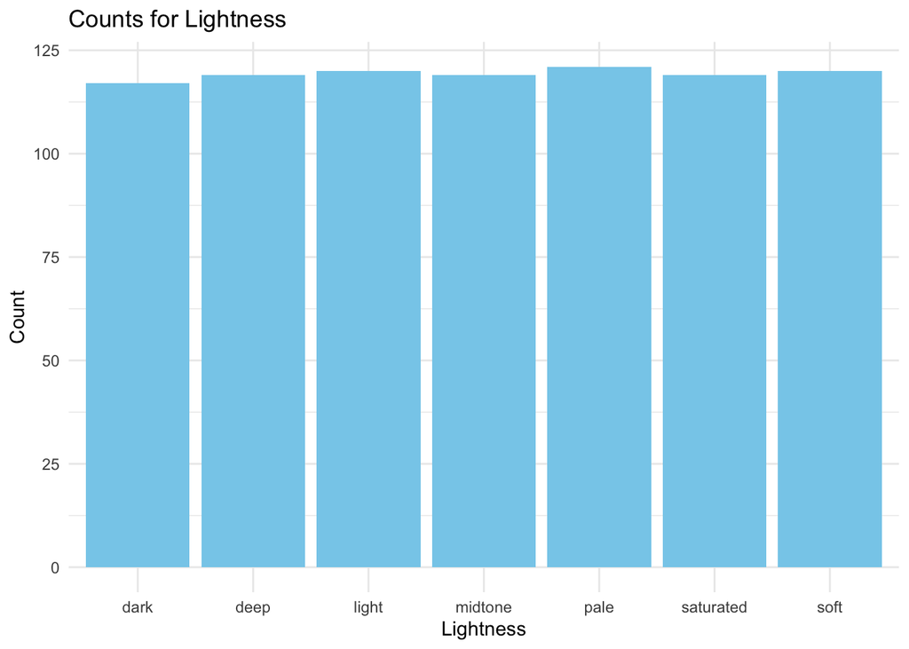

```r
library(ggplot2)

# Counts for Lightness
lightness_counts <- train_dataset %>%
  group_by(Lightness) %>%
  summarise(count = n())

# Bar plot for Lightness
ggplot(lightness_counts, aes(x = Lightness, y = count)) +
  geom_bar(stat = "identity", fill = "skyblue") +
  labs(title = "Counts for Lightness", x = "Lightness", y = "Count") +
  theme_minimal()
```

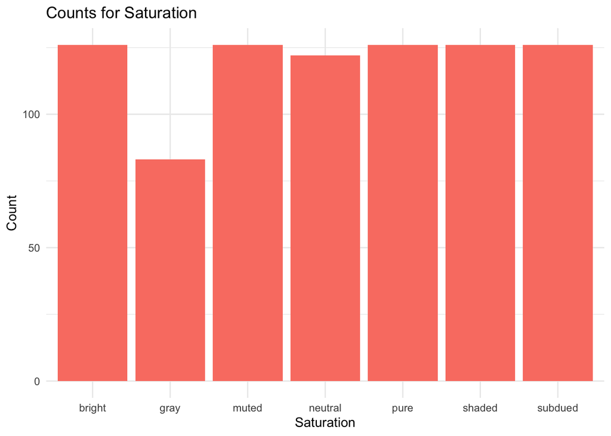

```r
# Counts for Saturation
saturation_counts <- train_dataset %>%
  group_by(Saturation) %>%
  summarise(count = n())

# Bar plot for Saturation
ggplot(saturation_counts, aes(x = Saturation, y = count)) +
  geom_bar(stat = "identity", fill = "salmon") +
  labs(title = "Counts for Saturation", x = "Saturation", y = "Count") +
  theme_minimal()
```

### Create histograms for continuous variables in the dataset

```r
library(gridExtra)
```

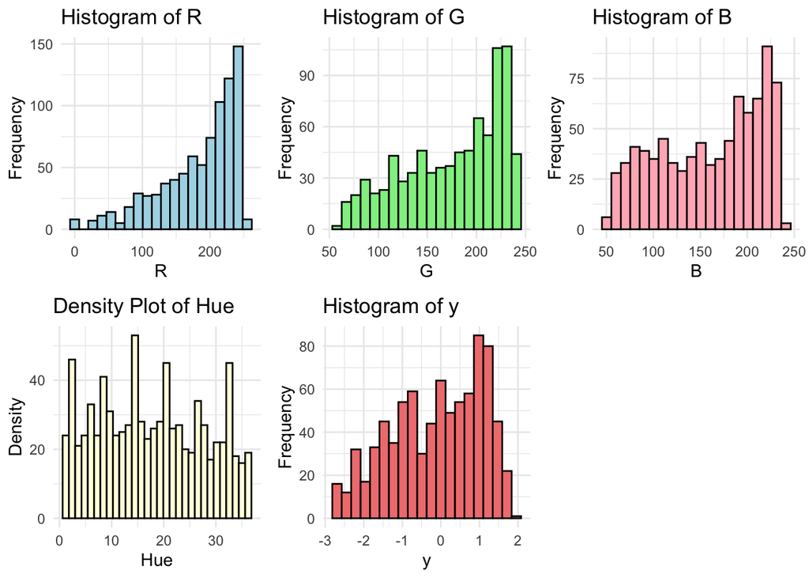

```r
# Histogram for R
histogram_R <- ggplot(train_dataset, aes(x = R)) +
  geom_histogram(fill = "lightblue", color = "black", bins = 20) +
  labs(title = "Histogram of R", x = "R", y = "Frequency") +
  theme_minimal()

# Histogram for G
histogram_G <- ggplot(train_dataset, aes(x = G)) +
  geom_histogram(fill = "lightgreen", color = "black", bins = 20) +
  labs(title = "Histogram of G", x = "G", y = "Frequency") +
  theme_minimal()

# Histogram for B
histogram_B <- ggplot(train_dataset, aes(x = B)) +
  geom_histogram(fill = "lightpink", color = "black", bins = 20) +
  labs(title = "Histogram of B", x = "B", y = "Frequency") +
  theme_minimal()

# Density plot for Hue
density_Hue <- ggplot(train_dataset, aes(x = Hue)) +
  geom_histogram(fill = "lightyellow", color = "black") +
  labs(title = "Density Plot of Hue", x = "Hue", y = "Density") +
  theme_minimal()

# Histogram for y, response transformed by logit
histogram_response <- ggplot(train_dataset, aes(x = y)) +
  geom_histogram(fill = "lightcoral", color = "black", bins = 20) +
  labs(title = "Histogram of y", x = "y", y = "Frequency") +
  theme_minimal()

# Combine plots into one grid
grid.arrange(histogram_R, histogram_G, histogram_B, density_Hue, histogram_response, ncol = 3)
```

Plotting a histogram of the data can provide a visual representation of the distribution’s shape. A Gaussian distribution typically appears symmetric with a bell-shaped curve. Are the distributions Gaussian like? The histogram for R, G B and hue does not look symmetric and they don’t look like gaussian.

At this point, I’m considering transforming R, G, B and hue values by logit. Applying a logit transformation is typically used to transform bounded or non-normal data to a more Gaussian-like distribution.

```r
# Apply logit transformation to R, G, B, and Hue
train_dataset$logit_R <- boot::logit((train_dataset$R - min(train_dataset$R)) / (max(train_dataset$R) - min(train_dataset$R)))
train_dataset$logit_G <- boot::logit((train_dataset$G - min(train_dataset$G)) / (max(train_dataset$G) - min(train_dataset$G)))
train_dataset$logit_B <- boot::logit((train_dataset$B - min(train_dataset$B)) / (max(train_dataset$B) - min(train_dataset$B)))
train_dataset$logit_Hue <- boot::logit((train_dataset$Hue - min(train_dataset$Hue)) / (max(train_dataset$Hue) - min(train_dataset$Hue)))

# View the modified dataset
head(train_dataset)
```

```
## # A tibble: 6 × 15
##       R     G     B Lightness Saturation   Hue response outcome LightnessNum
##   <dbl> <dbl> <dbl> <chr>     <chr>      <dbl>    <dbl>   <dbl>        <int>
## 1   172    58    62 dark      bright         4       12       1            1
## 2    26    88   151 dark      bright        31       10       1            1
## 3   172    94    58 dark      bright         8       16       1            1
## 4    28    87   152 dark      bright        32       10       0            1
## 5   170    66    58 dark      bright         5       11       0            1
## 6   175    89    65 dark      bright         6       16       0            1
## # ℹ 6 more variables: SaturationNum <int>, y <dbl>, logit_R <dbl>,
## #   logit_G <dbl>, logit_B <dbl>, logit_Hue <dbl>
```

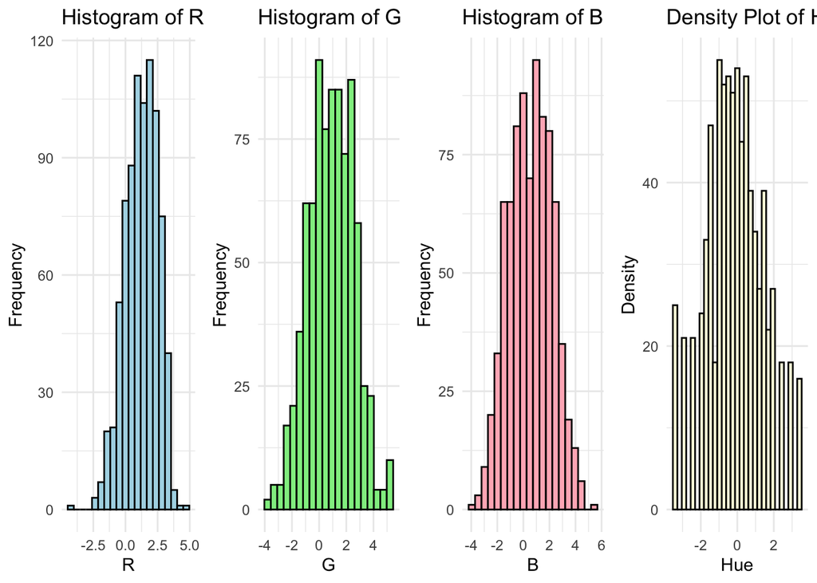

```r
library(gridExtra)

# Histogram for R
histogram_R <- ggplot(train_dataset, aes(x = logit_R)) +
  geom_histogram(fill = "lightblue", color = "black", bins = 20) +
  labs(title = "Histogram of R", x = "R", y = "Frequency") +
  theme_minimal()

# Histogram for G
histogram_G <- ggplot(train_dataset, aes(x = logit_G)) +
  geom_histogram(fill = "lightgreen", color = "black", bins = 20) +
  labs(title = "Histogram of G", x = "G", y = "Frequency") +
  theme_minimal()

# Histogram for B
histogram_B <- ggplot(train_dataset, aes(x = logit_B)) +
  geom_histogram(fill = "lightpink", color = "black", bins = 20) +
  labs(title = "Histogram of B", x = "B", y = "Frequency") +
  theme_minimal()

# Density plot for Hue
density_Hue <- ggplot(train_dataset, aes(x = logit_Hue)) +
  geom_histogram(fill = "lightyellow", color = "black") +
  labs(title = "Density Plot of Hue", x = "Hue", y = "Density") +
  theme_minimal()

# Combine plots into one grid
grid.arrange(histogram_R, histogram_G, histogram_B, density_Hue, ncol = 4)
```

## Condition (group) the continuous variables based on the categorical variables.

To group continuous input distributions based on the categorical input. We can use boxplots to focus on the distribution summary statistics. ### Grouping by Lightness

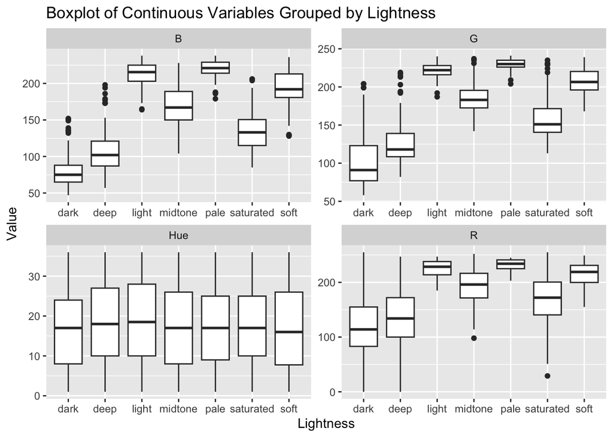

```r
# Convert data to long format
long_data <- train_dataset %>%
  pivot_longer(cols = c(R, G, B, Hue),
               names_to = "variable",
               values_to = "value")

# Create boxplot
ggplot(long_data, aes(x = Lightness, y = value)) +
  geom_boxplot() +
  facet_wrap(~ variable, scales = "free") +
  labs(x = "Lightness", y = "Value", title = "Boxplot of Continuous Variables Grouped by Lightness")
```

```r
# Compute summary statistics for each continuous variable grouped by different levels of the categorical variable
summary_stats <- train_dataset %>%
  group_by(Lightness) %>%
  summarize(
    mean_R = mean(R),
    median_R = median(R),
    sd_R = sd(R),
    mean_G = mean(G),
    median_G = median(G),
    sd_G = sd(G),
    mean_B = mean(B),
    median_B = median(B),
    sd_B = sd(B),
    mean_Hue = mean(Hue),
    median_Hue = median(Hue),
    sd_Hue = sd(Hue)
  )

# View the summary statistics
summary_stats
```

```
## # A tibble: 7 × 13
##   Lightness mean_R median_R  sd_R mean_G median_G  sd_G mean_B median_B  sd_B
##   <chr>      <dbl>    <dbl> <dbl>  <dbl>    <dbl> <dbl>  <dbl>    <dbl> <dbl>
## 1 dark        117.     114   58.9   104.      91  35.3    80.9      75   23.0
## 2 deep        134.     134   55.2   127.     118  29.6   108.      102   29.2
## 3 light       225.     228.  16.1   221.     222   9.90  212.      216.  16.0
## 4 midtone     192.     196   35.3   185.     183  20.3   170.      167   27.6
## 5 pale        232.     234   10.2   230.     230   6.94  220.      221   11.0
## 6 saturated   167.     172   47.0   158.     151  27.6   135.      133   27.4
## 7 soft        214.     219   23.9   207.     206. 16.0   193.      192   24.4
## # ℹ 3 more variables: mean_Hue <dbl>, median_Hue <dbl>, sd_Hue <dbl>
```

### Grouping by Saturation

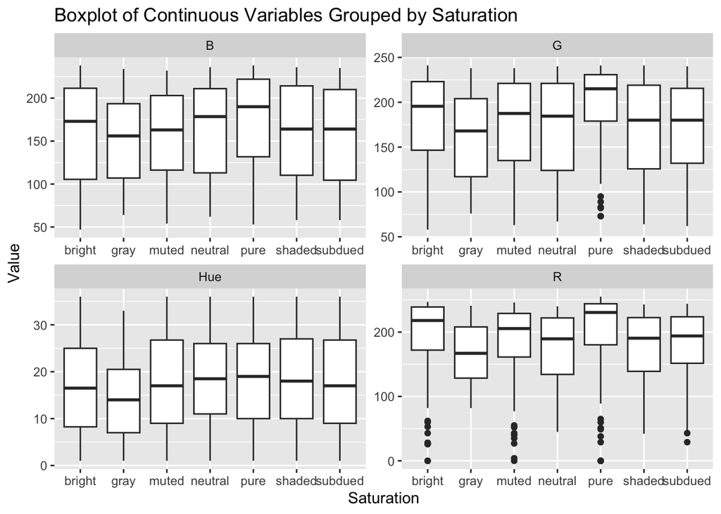

```r
# Create boxplot
ggplot(long_data, aes(x = Saturation, y = value)) +
  geom_boxplot() +
  facet_wrap(~ variable, scales = "free") +
  labs(x = "Saturation", y = "Value", title = "Boxplot of Continuous Variables Grouped by Saturation")
```

```r
# Compute summary statistics for each continuous variable grouped by different levels of the categorical variable
summary_stats <- train_dataset %>%
  group_by(Saturation) %>%
  summarize(
    mean_R = mean(R),
    median_R = median(R),
    sd_R = sd(R),
    mean_G = mean(G),
    median_G = median(G),
    sd_G = sd(G),
    mean_B = mean(B),
    median_B = median(B),
    sd_B = sd(B),
    mean_Hue = mean(Hue),
    median_Hue = median(Hue),
    sd_Hue = sd(Hue)
  )

# View the summary statistics
summary_stats
```

```
## # A tibble: 7 × 13
##   Saturation mean_R median_R  sd_R mean_G median_G  sd_G mean_B median_B  sd_B
##   <chr>       <dbl>    <dbl> <dbl>  <dbl>    <dbl> <dbl>  <dbl>    <dbl> <dbl>
## 1 bright       193.     218   62.3   181.     196.  47.6   158.     173   58.5
## 2 gray         167.     167   47.0   163.     168   48.6   154.     156   50.7
## 3 muted        186.     206.  57.7   174.     188.  50.4   158.     163   52.0
## 4 neutral      175.     190.  53.6   171.     184.  52.6   161.     178.  53.6
## 5 pure         200.     230.  64.0   199.     215   42.1   172.     190   55.7
## 6 shaded       176.     190.  54.4   170.     180   52.2   160.     164   54.7
## 7 subdued      181.     194   52.3   171.     180   49.8   156.     164   55.1
## # ℹ 3 more variables: mean_Hue <dbl>, median_Hue <dbl>, sd_Hue <dbl>
```

### Grouping by Outcome - binary variable.

We can include a logistic regression smoother to help visualize the changes in the event probability. You will use the geom_smooth() function to do so. The geom_jitter() function adds small amounts of random noise to “jitter” or perturb the locations of the points. This will make it easier to see the individual observations of the binary outcome. The formula argument are “local” variables associated with the aesthetics. Thus the formula y ~ x means the y aesthetic is linearly related to the x aesthetic. However, by specifying method = glm and method.args = list(family = ‘binomial’) instructing geom_smooth() to fit a logistic regression model. Thus, you are actually specifying that the linear predictor, the log-odds ratio is linearly related to the x aesthetic.

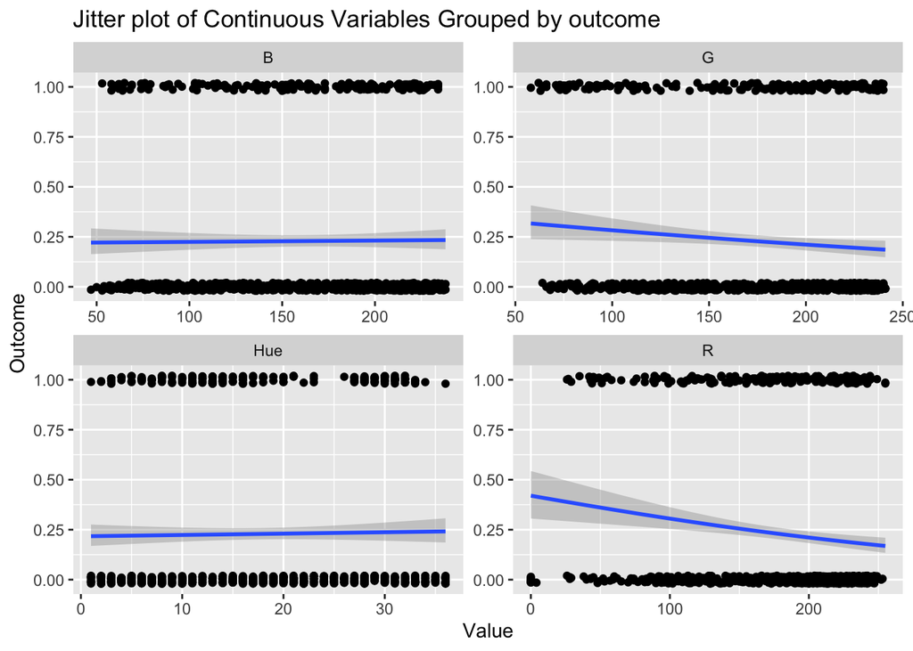

```r
ggplot(long_data, aes(x = value, y = outcome)) +
  geom_jitter(height = 0.02, width = 0) +
  geom_smooth(formula = y ~ x,
              method = glm,
              method.args = list(family = 'binomial')) +
  facet_wrap(~ variable, scales = "free") +
  labs(x = "Value", y = "Outcome", title = "Jitter plot of Continuous Variables Grouped by outcome")
```

```r
# Compute summary statistics for each continuous variable grouped by different levels of the categorical variable
summary_stats <- train_dataset %>%
  group_by(outcome) %>%
  summarize(
    mean_R = mean(R),
    median_R = median(R),
    sd_R = sd(R),
    mean_G = mean(G),
    median_G = median(G),
    sd_G = sd(G),
    mean_B = mean(B),
    median_B = median(B),
    sd_B = sd(B),
    mean_Hue = mean(Hue),
    median_Hue = median(Hue),
    sd_Hue = sd(Hue)
  )

# View the summary statistics
summary_stats
```

```
## # A tibble: 2 × 13
##   outcome mean_R median_R  sd_R mean_G median_G  sd_G mean_B median_B  sd_B
##     <dbl>  <dbl>    <dbl> <dbl>  <dbl>    <dbl> <dbl>  <dbl>    <dbl> <dbl>
## 1       0   187.     208.  55.9   179.     192.  48.1   160.     170.  55.2
## 2       1   170.     183   60.1   169.     183   55.8   161.     173   52.7
## # ℹ 3 more variables: mean_Hue <dbl>, median_Hue <dbl>, sd_Hue <dbl>
```

[figure not shown]

```r
# Create boxplot
ggplot(long_data, aes(x = as.factor(outcome), y = value)) +
  geom_boxplot() +
  facet_wrap(~ variable, scales = "free") +
  labs(x = "outcome", y = "Value", title = "Boxplot of Continuous Variables Grouped by Saturation")
```

## Visualize the relationships between the continuous inputs, are they correlated?

To visualize the relationships between continuous inputs and assess their correlation, we can create a correlation matrix and plot it using a heatmap. This heatmap will provide a visual representation of the correlation coefficients between pairs of continuous variables.

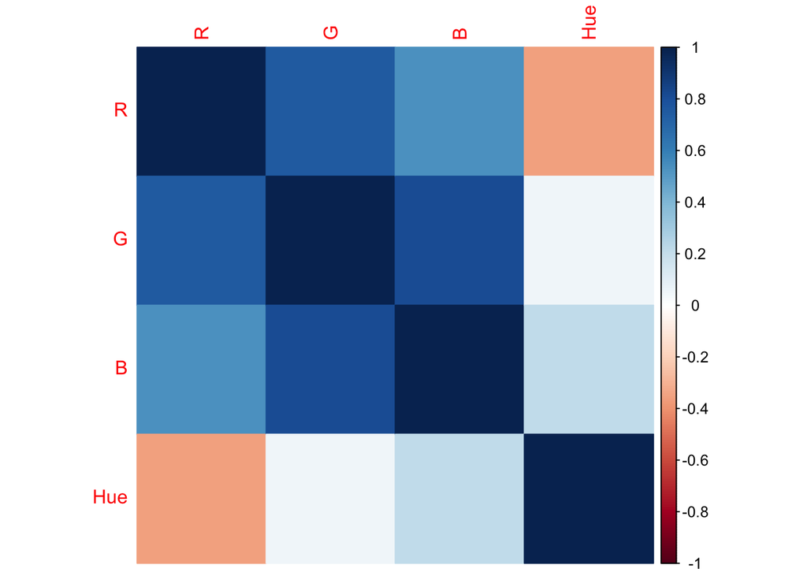

```r
# Subset the dataframe to include only the continuous variables
# Convert correlation matrix to data frame
df <- as.data.frame(train_dataset)
continuous_vars <- df[, c("R", "G", "B", "Hue")]

# Compute the correlation matrix
correlation_matrix <- cor(continuous_vars)

# Visualize the correlation matrix using a heatmap
library(corrplot)
corrplot(correlation_matrix, method = "color")
```

## Visualize the relationships between the continuous outputs (response and the LOGIT-transformed response, y) with respect to the continuous INPUTS.

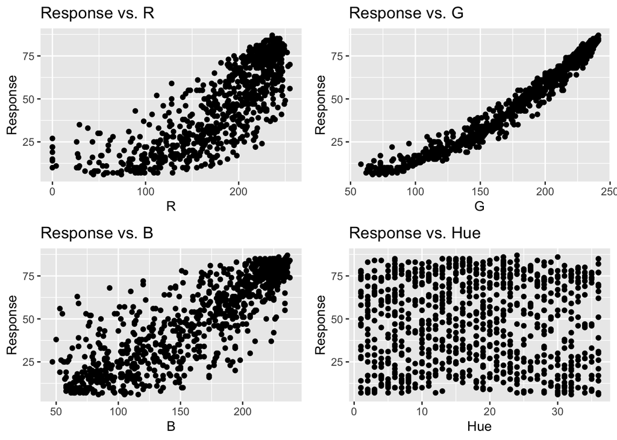

```r
library(gridExtra)

# Scatter plots for response vs. continuous inputs
scatter_plots_response <- lapply(c("R", "G", "B", "Hue"), function(variable) {
  ggplot(train_dataset, aes_string(x = variable, y = "response")) +
    geom_point() +
    labs(x = variable, y = "Response", title = paste("Response vs.", variable))
})
# Scatter plots for y vs. continuous inputs
scatter_plots_y <- lapply(c("R", "G", "B", "Hue"), function(variable) {
  ggplot(train_dataset, aes_string(x = variable, y = "y")) +
    geom_point() +
    labs(x = variable, y = "Logit-transformed Response (y)", title = paste("y vs.", variable))
})

# Combine scatter plots for response into a grid
grid_response <- do.call(grid.arrange, c(scatter_plots_response, ncol = 2))
```

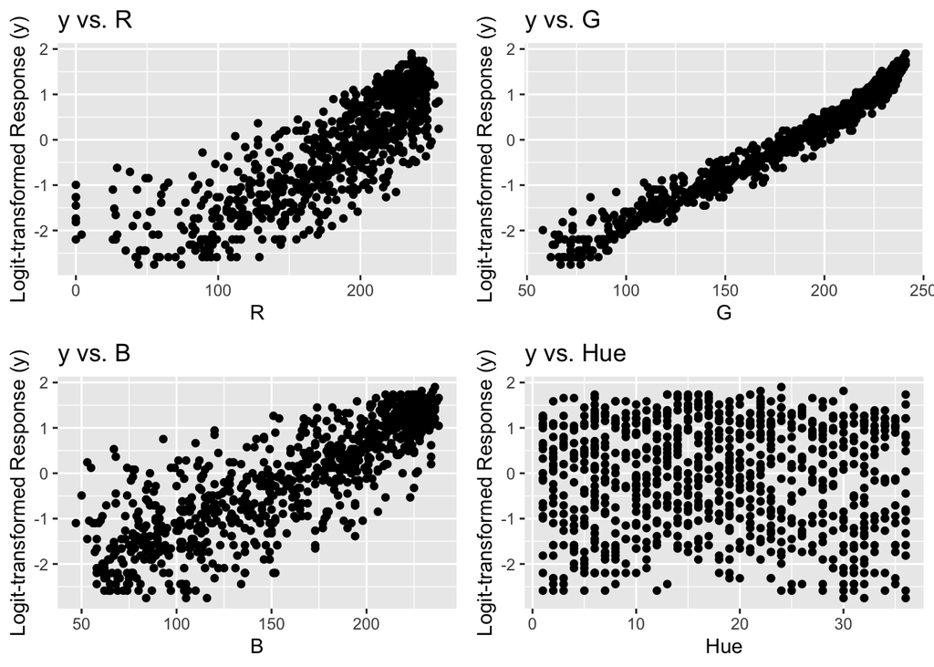

```r
# Combine scatter plots for y into a grid
grid_y <- do.call(grid.arrange, c(scatter_plots_y, ncol = 2))
```

```r
# Show the grids
grid_response
```

```r
grid_y
```

### Can you identify any clear trends?

Yes, Explanation of the trends observed in the scatter plots: 1. **R, G, B Trends**: - The plots for G exhibit a linear trend, with all data points closely aligned along a steeply sloping line. This suggests a strong positive correlation between higher values of G and elevated logit-transformed response values. - In the scatter plots for R, G, and B versus response (paint property), we observe a clear trend where the points tend to form a line that slopes upwards with a positive slope showing linear relationship. - This upward trend indicates that as the values of R, G, and B increase, the corresponding response values also tend to increase. - The density of points is higher towards the upper end of the color spectrum, indicating that paints with higher RGB values (i.e., brighter colors) tend to have higher response values, suggesting they are associated with more favorable paint properties. - Conversely, for lower values of R, G, and B (darker colors), the response values are more scattered, indicating a wider variability in paint properties. - While the plots for R and B also display a slanting line indicative of a positive correlation, the points are more scattered. This implies that while higher values of R and B tend to correspond to increased logit-transformed response values, the relationship is not as tightly defined as in the case of G.

2. **Hue Trend**:
   - In contrast to R, G, and B, the scatter plot for Hue versus response does not exhibit a clear pattern or trend.
   - The points are scattered across the plot without showing any discernible relationship between Hue and response.
   - This lack of trend suggests that the Hue component alone may not be a significant predictor of paint properties, at least not in a linear relationship.

Sure, here’s the code to visualize the binary outcome with respect to the continuous inputs using scatterplots with jitter and logistic regression smoother, combined in a grid:

## How can you visualize the behavior of the binary outcome with respect to the continuous inputs?

- We can use geom_jitter() function.
- Scatterplots with jitter and logistic regression smoother help visualize the relationship between continuous inputs and binary outcomes.
- Jitter is added to the points to prevent overplotting and make individual observations visible.
- The logistic regression smoother provides an estimate of the probability of the binary outcome based on the continuous input, showing how the probability changes with the input variable.
- These plots help identify trends and patterns in the relationship between continuous inputs and binary outcomes, aiding in understanding the predictive power of the continuous variables for the binary outcome.

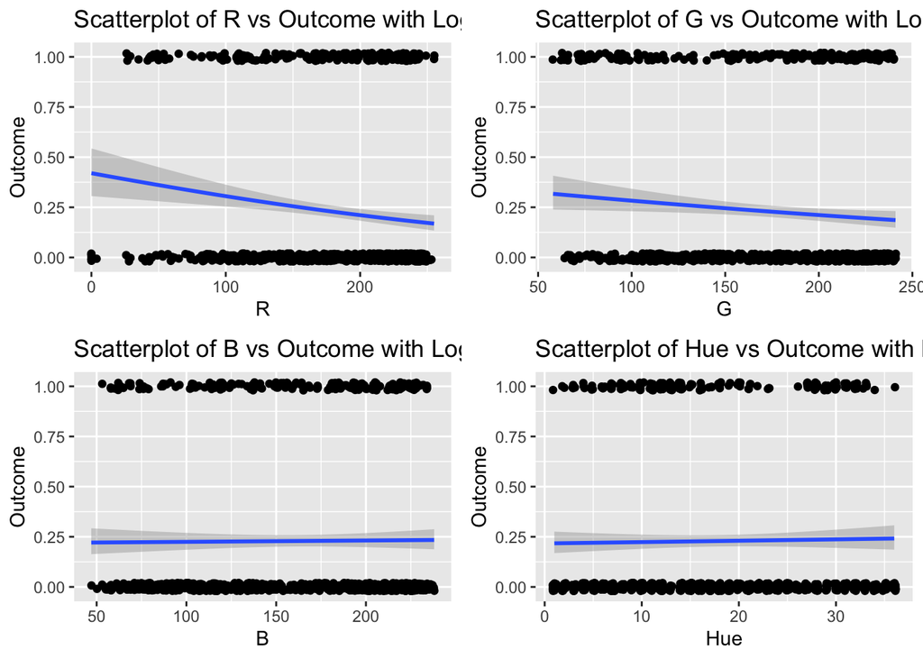

```r
# Create scatterplots of each continuous input against the binary outcome with logistic regression smoother
scatterplot_R <- ggplot(train_dataset, aes(x = R, y = outcome)) +
  geom_jitter(width = 0.2, height = 0.02) +
  geom_smooth(method = "glm", method.args = list(family = "binomial")) +
  labs(x = "R", y = "Outcome", title = "Scatterplot of R vs Outcome with Logistic Regression Smoother")

scatterplot_G <- ggplot(train_dataset, aes(x = G, y = outcome)) +
  geom_jitter(width = 0.2, height = 0.02) +
  geom_smooth(method = "glm", method.args = list(family = "binomial")) +
  labs(x = "G", y = "Outcome", title = "Scatterplot of G vs Outcome with Logistic Regression Smoother")

scatterplot_B <- ggplot(train_dataset, aes(x = B, y = outcome)) +
  geom_jitter(width = 0.2, height = 0.02) +
  geom_smooth(method = "glm", method.args = list(family = "binomial")) +
  labs(x = "B", y = "Outcome", title = "Scatterplot of B vs Outcome with Logistic Regression Smoother")

scatterplot_Hue <- ggplot(train_dataset, aes(x = Hue, y = outcome)) +
  geom_jitter(width = 0.2, height = 0.02) +
  geom_smooth(method = "glm", method.args = list(family = "binomial")) +
  labs(x = "Hue", y = "Outcome", title = "Scatterplot of Hue vs Outcome with Logistic Regression Smoother")

# Combine all scatterplots in a grid
grid.arrange(scatterplot_R, scatterplot_G, scatterplot_B, scatterplot_Hue, ncol = 2)
```

## How can you visualize the behavior of the binary outcome with respect to the categorical INPUTS? We can create a bar chart for the categorical input x1 with ggplot2 and can fill aesthetic to as.factor(y). The data type conversion function as.factor() can be applied in-line. This will force a categorical fill palette to be used rather than a continuous palette. Visualization

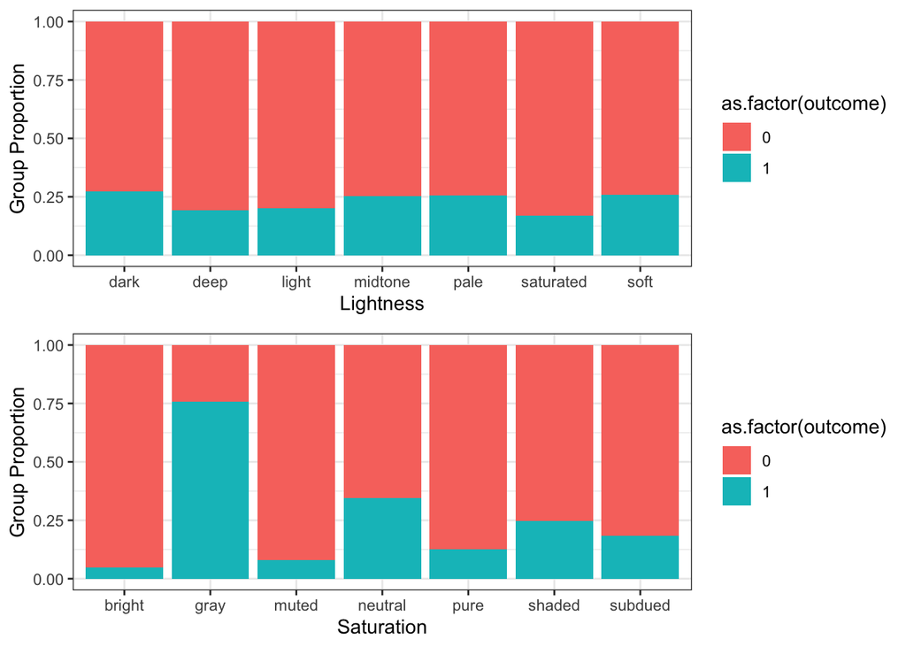

```r
# Create the first bar chart
plot1 <- train_dataset %>%
  ggplot(mapping = aes(x = Lightness)) +
  geom_bar(mapping = aes(fill = as.factor(outcome)), position = 'fill') +
  labs(y = 'Group Proportion') +
  theme_bw()

# Create the second bar chart
plot2 <- train_dataset %>%
  ggplot(mapping = aes(x = Saturation)) +
  geom_bar(mapping = aes(fill = as.factor(outcome)), position = 'fill') +
  labs(y = 'Group Proportion') +
  theme_bw()

# Combine the plots into a grid
grid.arrange(plot1, plot2, ncol = 1)
```

Observations:

Lightness: - In the graph for lightness, each value corresponding to dark, deep, light, midtone, pale, saturated, and soft has approximately 75% of outcome 0 (not liked by people) and 25% of outcome 1 (liked by people). - This suggests that there is no significant variation in the proportion of liked and not liked outcomes across different lightness values. Lightness alone may not be a strong predictor of paint color popularity.

Saturation: - In the graph for saturation, only the gray color has a higher number of outcome 1 (liked by people), while the rest of the values like bright, muted, neutral, pure, shaded, and subdued have a lower number of outcome 1. - This indicates that paint colors with a gray saturation tend to be liked by people more often compared to other saturation levels. - Saturation might have a more noticeable impact on paint color popularity compared to lightness, as certain saturation levels are associated with higher proportions of liked outcomes.

Overall, while lightness alone does not show a clear trend in paint color popularity, saturation, particularly gray saturation, appears to have a stronger influence on whether a paint color is liked or not liked by people. I also combined both the categorical inputs (Lightness and Saturation) based on outcome (binary). The graph visualizes the relationship between three categorical variables: 1. Lightness: This likely refers to the lightness or darkness of a color. 2. Saturation: This likely refers to the intensity or purity of a color. 3. Outcome: This is a binary variable, possibly representing some classification or grouping (represented by the colors in the bars).

Below are my observations on the combination and how outcome is impacted: In the combined plot, the gray saturation level appears to have a consistent trend across different lightness values. Specifically, for all lightness values (dark, deep, light, midtone, pale, saturated, and soft), the gray saturation level consistently exhibits the highest proportion of outcome 1, indicating popularity compared to all other saturation levels.

This suggests that paint colors with a gray saturation level are generally preferred or liked by people across a wide range of lightness values. Gray saturation might have a universal appeal or aesthetic attractiveness that transcends differences in lightness.

Additionally, this observation underscores the importance of considering both saturation and lightness in understanding the popularity of paint colors. While lightness contributes to the perception of brightness or darkness, saturation plays a crucial role in determining the intensity or purity of a color. In this case, the combination of gray saturation with various lightness values consistently results in higher proportions of liked outcomes, highlighting the significance of color intensity in paint color preference.

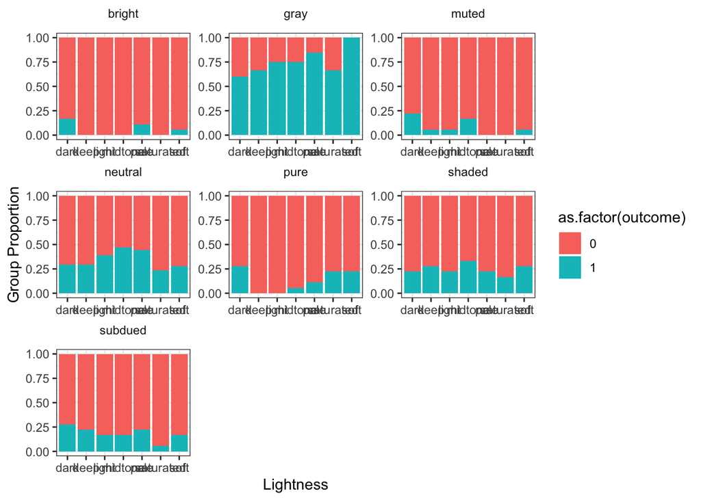

```r
# Combine the two bar charts using facets with space between facets
combined_plot <- train_dataset %>%
  ggplot() +
  geom_bar(mapping = aes(x = Lightness, fill = as.factor(outcome)), position = 'fill') +
  facet_wrap(~Saturation, scales = 'free') +  # Allow scales to be free
  labs(y = 'Group Proportion') +
  theme_bw() +
  theme(
    strip.text = element_text(margin = margin(b = 10)),  # Add margin to text
    strip.background = element_rect(fill = 'white', color = 'white')  # Make background white
  )

# Display the combined plot
print(combined_plot)
```

## Saving the preprocessed dataset for next parts.

```r
train_dataset %>% readr::write_rds("my_train_data.rds")
df %>% readr::write_rds("df.rds")
```